# MonsterBasicAnalysis

```python
import pandas as pd
import numpy as np
import matplotlib.pyplot as plt
import seaborn as sns
import re
import string
from sklearn import linear_model
from sklearn.feature_selection import SelectFromModel
from sklearn.model_selection import train_test_split
from sklearn.ensemble import RandomForestRegressor
from sklearn.model_selection import RandomizedSearchCV
from sklearn.model_selection import GridSearchCV
from scipy import stats
```

I have previously scraped a bunch of data about DnD monsters from [orcpub](http://www.orcpub.com/dungeons-and-dragons/5th-edition/monsters) using `MonsterScraper.py`. The first thing I want to do is load the data from the created csv file into a dataframe.

```python
df = pd.read_csv('monsters.csv')
df.head()
```

|  | Name | Size | Type | Alignment | AC | HP | Hit Die | Speed | Str | Dex | ... | Skills | Resistance | Immunity | Condition Immunity | Senses | Languages | CR | Extras | Actions | Leg Actions |
| --- | --- | --- | --- | --- | --- | --- | --- | --- | --- | --- | --- | --- | --- | --- | --- | --- | --- | --- | --- | --- | --- |
| 0 | Aboleth | Large | aberration | lawful evil | 17 | 135 | (18d10+ 36) | 10 ft., swim 40 ft. ft. | 21 (+5) | 9 (-1) | ... | History +12, Perception +10 | NaN | NaN | NaN | darkvision 120 ft., passive Perception 20 | Deep Speech, telepathy 120 ft. | 10(5900 XP) | Amphibious.Mucous Cloud.Probing Telepathy. | Multiattack.Tentacle.Tail.Enslave . | Detect.Tail Swipe.Psychic Drain . |
| 1 | Deva | Medium | celestial | lawful good | 17 | 136 | (16d8+ 64) | 30 ft., fly 90 ft. ft. | 18 (+4) | 18 (+4) | ... | Insight +9, Perception +9 | radiant; bludgeoning, piercing, and slashing f... | NaN | charmed, exhaustion, frightened | darkvision 120 ft., passive Perception 19 | all, telepathy 120 ft. | 10(5900 XP) | Angelic Weapons.Innate Spellcasting.Magic Resi... | Multiattack.Mace.Healing Touch .Change Shape. | NaN |
| 2 | Planetar | Large | celestial | lawful good | 19 | 200 | (16d10+ 112) | 40 ft., fly 120 ft. ft. | 24 (+7) | 20 (+5) | ... | Perception +11 | radiant; bludgeoning, piercing, and slashing f... | NaN | charmed, exhaustion, frightened | truesight 120 ft., passive Perception 21 | all, telepathy 120 ft. | 16(15000 XP) | Angelic Weapons.Divine Awareness.Innate Spellc... | Multiattack.Greatsword.Healing Touch . | NaN |
| 3 | Solar | Large | celestial | lawful good | 21 | 243 | (18d10+ 144) | 50 ft., fly 150 ft. ft. | 26 (+8) | 22 (+6) | ... | Perception +14 | radiant; bludgeoning, piercing, and slashing f... | necrotic, poison | charmed, exhaustion, frightened, poisoned | truesight 120 ft., passive Perception 24 | all, telepathy 120 ft. | 21(33000 XP) | Angelic Weapons.Divine Awareness.Innate Spellc... | Multiattack.Greatsword.Slaying Longbow.Flying ... | Teleport.Searing Burst .Blinding Gaze . |
| 4 | Animated Armor | Medium | construct | unaligned | 18 | 33 | (6d8+ 6) | 25 ft. ft. | 14 (+2) | 11 (0) | ... | NaN | NaN | poison, psychic | blinded, charmed, deafened, exhaustion, fright... | blindsight 60 ft. (blind beyond this radius), ... | NaN | 1(200 XP) | Antimagic Susceptibility.False Appearance. | Multiattack.Slam. | NaN |

5 rows × 25 columns

Let's take a look at all of the columns available

```python
print(df.columns)
```

```
Index(['Name', 'Size', 'Type', 'Alignment', 'AC', 'HP', 'Hit Die', 'Speed',
       'Str', 'Dex', 'Con', 'Int', 'Wis', 'Cha', 'Proficiency', 'Skills',
       'Resistance', 'Immunity', 'Condition Immunity', 'Senses', 'Languages',
       'CR', 'Extras', 'Actions', 'Leg Actions'],
      dtype='object')
```

```python
df.describe()
```

|  | AC | HP | Proficiency |
| --- | --- | --- | --- |
| count | 317.000000 | 317.000000 | 317.000000 |
| mean | 14.069401 | 82.309148 | 2.876972 |
| std | 3.269766 | 99.875329 | 1.432226 |
| min | 5.000000 | 1.000000 | 2.000000 |
| 25% | 12.000000 | 18.000000 | 2.000000 |
| 50% | 13.000000 | 45.000000 | 2.000000 |
| 75% | 17.000000 | 114.000000 | 3.000000 |
| max | 25.000000 | 676.000000 | 9.000000 |

## Basic Data Cleaning

It's easy to see that some of the data that is likely important to understanding the strength of a monster needs to be cleaned. This includes hit die, and the attributes such as strength, dexterity, etc. First, I am going to make three columns representing the number of die, the type of die, and the additional modifier.

```python
#not the nicest/most efficient, gets the job done for now
# new data frame with split value columns
#Remove the brackets from the column
def sanitize_hit_die(word):
    #clean up parentheses
    word = word.translate(str.maketrans('','','()'))
    #check for offset modifier, if not add a + 0
    if not re.search('\+|\-',word):
        word += '+ 0'
    #are we using positive or negative modifiers?
    sign = re.findall('\+|\-',word)
    word_list = re.split('\D |\D',word)
    word_list[2] = sign[0] + word_list[2]
    return word_list

df[["N Hit Die", "Dice", "Offset"]] = df['Hit Die'].apply(lambda row: pd.Series(sanitize_hit_die(row)))

df = df.drop("Hit Die",axis=1)

df.head()
```

|  | Name | Size | Type | Alignment | AC | HP | Speed | Str | Dex | Con | ... | Condition Immunity | Senses | Languages | CR | Extras | Actions | Leg Actions | N Hit Die | Dice | Offset |
| --- | --- | --- | --- | --- | --- | --- | --- | --- | --- | --- | --- | --- | --- | --- | --- | --- | --- | --- | --- | --- | --- |
| 0 | Aboleth | Large | aberration | lawful evil | 17 | 135 | 10 ft., swim 40 ft. ft. | 21 (+5) | 9 (-1) | 15 (+2) | ... | NaN | darkvision 120 ft., passive Perception 20 | Deep Speech, telepathy 120 ft. | 10(5900 XP) | Amphibious.Mucous Cloud.Probing Telepathy. | Multiattack.Tentacle.Tail.Enslave . | Detect.Tail Swipe.Psychic Drain . | 18 | 10 | +36 |
| 1 | Deva | Medium | celestial | lawful good | 17 | 136 | 30 ft., fly 90 ft. ft. | 18 (+4) | 18 (+4) | 18 (+4) | ... | charmed, exhaustion, frightened | darkvision 120 ft., passive Perception 19 | all, telepathy 120 ft. | 10(5900 XP) | Angelic Weapons.Innate Spellcasting.Magic Resi... | Multiattack.Mace.Healing Touch .Change Shape. | NaN | 16 | 8 | +64 |
| 2 | Planetar | Large | celestial | lawful good | 19 | 200 | 40 ft., fly 120 ft. ft. | 24 (+7) | 20 (+5) | 24 (+7) | ... | charmed, exhaustion, frightened | truesight 120 ft., passive Perception 21 | all, telepathy 120 ft. | 16(15000 XP) | Angelic Weapons.Divine Awareness.Innate Spellc... | Multiattack.Greatsword.Healing Touch . | NaN | 16 | 10 | +112 |
| 3 | Solar | Large | celestial | lawful good | 21 | 243 | 50 ft., fly 150 ft. ft. | 26 (+8) | 22 (+6) | 26 (+8) | ... | charmed, exhaustion, frightened, poisoned | truesight 120 ft., passive Perception 24 | all, telepathy 120 ft. | 21(33000 XP) | Angelic Weapons.Divine Awareness.Innate Spellc... | Multiattack.Greatsword.Slaying Longbow.Flying ... | Teleport.Searing Burst .Blinding Gaze . | 18 | 10 | +144 |
| 4 | Animated Armor | Medium | construct | unaligned | 18 | 33 | 25 ft. ft. | 14 (+2) | 11 (0) | 13 (+1) | ... | blinded, charmed, deafened, exhaustion, fright... | blindsight 60 ft. (blind beyond this radius), ... | NaN | 1(200 XP) | Antimagic Susceptibility.False Appearance. | Multiattack.Slam. | NaN | 6 | 8 | +6 |

5 rows × 27 columns

Now I will break apart the abilities and their modifiers while also sanitizing. It will be helpful to have a function do the work as I will need to do this multiple times.

```python
def sanitize_abilities(word):
    return re.split('[\(\)]', word)[0:2]

df[['Str','Str_mod']] = df['Str'].apply(lambda row: pd.Series(sanitize_abilities(row)))
df[['Dex','Dex_mod']] = df['Dex'].apply(lambda row: pd.Series(sanitize_abilities(row)))
df[['Cha','Cha_mod']] = df['Cha'].apply(lambda row: pd.Series(sanitize_abilities(row)))
df[['Con','Con_mod']] = df['Con'].apply(lambda row: pd.Series(sanitize_abilities(row)))
df[['Wis','Wis_mod']] = df['Wis'].apply(lambda row: pd.Series(sanitize_abilities(row)))
df[['Int','Int_mod']] = df['Int'].apply(lambda row: pd.Series(sanitize_abilities(row)))
```

The last thing I'm going to do for basic numeric values is break apart the CR and XP values. These currently look like this:

```python
df.CR.head()
```

```
0     10(5900 XP)
1     10(5900 XP)
2    16(15000 XP)
3    21(33000 XP)
4       1(200 XP)
Name: CR, dtype: object
```

Here I will seperate the CR and XP values, and put them in their own columns.

```python
def clean_CR(word):
    columns = word.split('(')
    columns[1] = columns[1].split()[0]
    return columns

df[['CR','XP']] = df['CR'].apply(lambda row: pd.Series(clean_CR(row)))
df[['XP','CR']].head() #shows section we are interested to see if it worked
```

|  | XP | CR |
| --- | --- | --- |
| 0 | 5900 | 10 |
| 1 | 5900 | 10 |
| 2 | 15000 | 16 |
| 3 | 33000 | 21 |
| 4 | 200 | 1 |

The quantitative features should be converted to numeric values. As shown below, ability values are currently given as strings. Some of the numeric values are also given as fractions and need to be converted to floats by hand. This creates the need to use a custom float creator before the `pd.to_numeric`

```python
print(df.dtypes)
```

```
Name                   object
Size                   object
Type                   object
Alignment              object
AC                      int64
HP                      int64
Speed                  object
Str                    object
Dex                    object
Con                    object
Int                    object
Wis                    object
Cha                    object
Proficiency           float64
Skills                 object
Resistance             object
Immunity               object
Condition Immunity     object
Senses                 object
Languages              object
CR                     object
Extras                 object
Actions                object
Leg Actions            object
N Hit Die              object
Dice                   object
Offset                 object
Str_mod                object
Dex_mod                object
Cha_mod                object
Con_mod                object
Wis_mod                object
Int_mod                object
XP                     object
dtype: object
```

```python
def convert_to_float(frac_str):
    try:
        return float(frac_str)
    except ValueError:
        num, denom = frac_str.split('/')
        try:
            leading, num = num.split(' ')
            whole = float(leading)
        except ValueError:
            whole = 0
        frac = float(num) / float(denom)
        return whole - frac if whole < 0 else whole + frac
```

```python
make_num_list = ["Str","Dex","Con","Int","Wis","Cha","N Hit Die","Dice","Offset","Str_mod","Dex_mod","Cha_mod","Con_mod","Wis_mod","Int_mod","XP","CR"]
#make_num_list = "Str"
df[make_num_list] = df[make_num_list].applymap(convert_to_float)
```

## Initial Checks

One would expect XP and CR to be related. The amount of correlation should be checked, as it is very likely that the XP is deduced from the CR. If this is the case it would lead to leakage in our model.

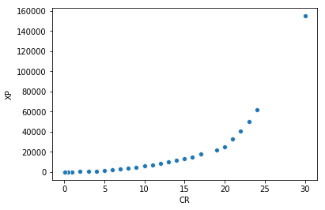

```python
sns.scatterplot(x=df.CR,y=df.XP)
plt.show()
```

There is an interesting trend between the XP given out and the CR of a monster. There is also clearly not a lot of scatter between each CR and XP. Looking for the number of unique XP values for each CR clearly shows that there is a one-to-one relationship between CR and XP. Clearly we must not use XP for modelling the determination of CR as we will have significant data leakage.

```python
df.groupby('CR').XP.nunique()
```

```
CR
0.000     1
0.125     1
0.250     1
0.500     1
1.000     1
2.000     1
3.000     1
4.000     1
5.000     1
6.000     1
7.000     1
8.000     1
9.000     1
10.000    1
11.000    1
12.000    1
13.000    1
14.000    1
15.000    1
16.000    1
17.000    1
19.000    1
20.000    1
21.000    1
22.000    1
23.000    1
24.000    1
30.000    1
Name: XP, dtype: int64
```

Now, we want to simplify the feature list to look at the basic quantitative features without XP. Perhaps we will go back to the more complicated traits later, but let's see if we can build a model without sinking too much time into other features. Adding additional traits will likely require building an actions table (and corresponding NLP) along with one-hot encoding. The modifiers will also be left out as they very much related to the proficiency and attribute.

```python
X_list = ["Str","Dex","Con","Int","Wis","Cha","Proficiency","AC","HP"]
X = df[X_list]
y_list = ["CR"]
y = df[y_list]
```

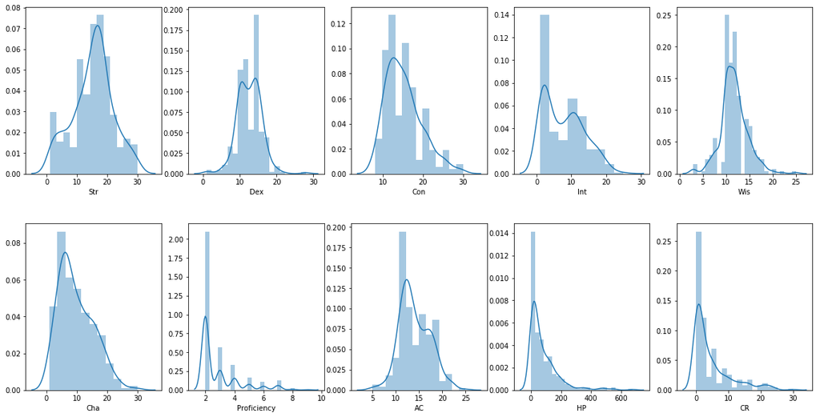

```python
fig, axs = plt.subplots(figsize=(20,10),ncols=5,nrows=2)
sns.distplot(a=X.Str,ax=axs[0][0])
sns.distplot(a=X.Dex,ax=axs[0][1])
sns.distplot(a=X.Con,ax=axs[0][2])
sns.distplot(a=X.Int,ax=axs[0][3])
sns.distplot(a=X.Wis,ax=axs[0][4])
sns.distplot(a=X.Cha,ax=axs[1][0])
sns.distplot(a=X.Proficiency,ax=axs[1][1])
sns.distplot(a=X.AC,ax=axs[1][2])
sns.distplot(a=X.HP,ax=axs[1][3])
sns.distplot(a=y.CR,ax=axs[1][4])
plt.subplots_adjust(hspace=0.3, wspace=0.2)
plt.show()
```

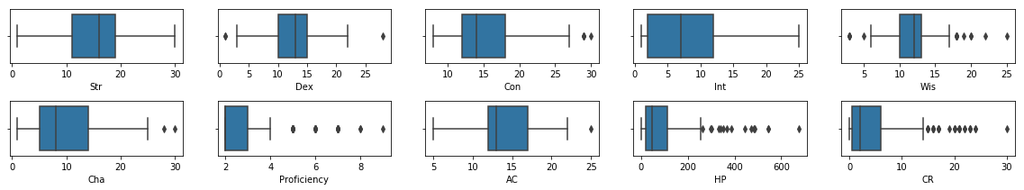

```python
fig, axs = plt.subplots(figsize=(20,3),ncols=5,nrows=2)
sns.boxplot(x=X.Str,ax=axs[0][0])
sns.boxplot(x=X.Dex,ax=axs[0][1])
sns.boxplot(x=X.Con,ax=axs[0][2])
sns.boxplot(x=X.Int,ax=axs[0][3])
sns.boxplot(x=X.Wis,ax=axs[0][4])
sns.boxplot(x=X.Cha,ax=axs[1][0])
sns.boxplot(x=X.Proficiency,ax=axs[1][1])
sns.boxplot(x=X.AC,ax=axs[1][2])
sns.boxplot(x=X.HP,ax=axs[1][3])
sns.boxplot(x=y.CR,ax=axs[1][4])
plt.subplots_adjust(hspace=0.7, wspace=0.2)
plt.show()
```

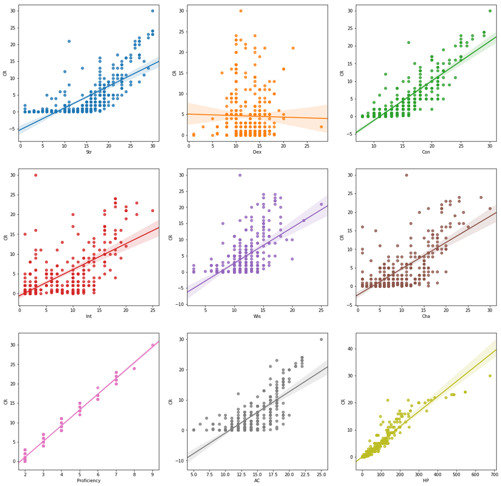

```python
fig, axs = plt.subplots(figsize=(20,20),ncols=3,nrows=3)
sns.regplot(x=X.Str,y=y.CR,ax=axs[0][0])
sns.regplot(x=X.Dex,y=y.CR,ax=axs[0][1])
sns.regplot(x=X.Con,y=y.CR,ax=axs[0][2])
sns.regplot(x=X.Int,y=y.CR,ax=axs[1][0])
sns.regplot(x=X.Wis,y=y.CR,ax=axs[1][1])
sns.regplot(x=X.Cha,y=y.CR,ax=axs[1][2])
sns.regplot(x=X.Proficiency,y=y.CR,ax=axs[2][0])
sns.regplot(x=X.AC,y=y.CR,ax=axs[2][1])
sns.regplot(x=X.HP,y=y.CR,ax=axs[2][2])
plt.subplots_adjust(hspace=0.2, wspace=0.2)
plt.show()
```

The eye test suggests that HP and Proficiency may be strongly, linearly correlated with CR. Let's model these data with a multiple linear regression and see how good we can do.

## Splitting the data

First thing is to split the data into a training and testing set.

```python
X_train_val, X_test, y_train_val, y_test = train_test_split(X, y, test_size=0.2, random_state=0)
X_train, X_val, y_train, y_val = train_test_split(X_train_val, y_train_val, test_size=0.2, random_state=0)
```

## Distribution of errors/Measure of accuracy

The measurement of accuracy will be based on the mean absolute error (MAE) and the standard deviation of the errors in the predictions.

```python
def prediction_difference_list(prediction,actual):
    return [ (prediction[i] - actual[i]) for i in range(len(prediction))]

def mean_absolute_error(prediction,actual):
    abs_error = [ abs(prediction[i] - actual[i]) for i in range(len(prediction)) ]
    return np.mean(abs_error)

def accuracy(prediction,actual):
    prediction_diff = prediction_difference_list(prediction,actual)
    mae = mean_absolute_error(prediction, actual)
    sns.distplot(a=prediction_diff);
    print("Mean Abs Error = " + str(mae))
    print("{0} +/- {1}".format(np.mean(prediction_diff),np.std(prediction_diff)))
    plt.show()
```

## Multiple Linear Regression on the clear predictors HP and Profficiency

```python
regr = linear_model.LinearRegression()
regr.fit(X_train[["HP","Proficiency"]], y_train)
print('Intercept: \n', regr.intercept_)
print('Coefficients: \n', regr.coef_)
```

```
Intercept:
 [-5.49820054]
Coefficients:
 [[0.01595229 3.05958737]]
```

How well does this model do as is?

```
Mean Abs Error = 0.6924929775114314
-0.054380106305394645 +/- 0.910663286165311
```

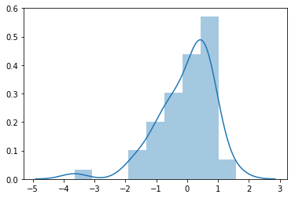

```python
y_pred_mr = regr.predict(X_val[["HP","Proficiency"]])
accuracy(y_pred_mr,y_val.CR.to_list())
```

So this model gets us pretty close on average and generally within +/- 2 on the value of CR. This is a pretty good baseline as the model is dead simple. The next step is to see if we can improve this model. It also seems like we are slightly underpredicting some of the CR values. We should check if there are any less obvious correlations in the other variables.

## Feature selection and ML

```
Mean Abs Error = 0.6924929775114314
-0.054380106305394645 +/- 0.910663286165311
```

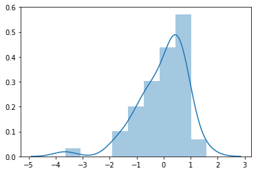

```python
rf_model = RandomForestRegressor(n_estimators=1000, random_state=1)
rf_model.fit(X_train,y_train.values.ravel())

y_pred_rf = rf_model.predict(X_val)
accuracy(y_pred_mr,y_val.CR.to_list())
```

```python
# Get numerical feature importances
importances = list(rf_model.feature_importances_)
feature_importances = [(feature, round(importance, 2)) for feature, importance in zip(X_train, importances)]
# Sort the feature importances by most important first
feature_importances = sorted(feature_importances, key = lambda x: x[1], reverse = True)
# Print out the feature and importances
[print('Variable: {:20} Importance: {}'.format(*pair)) for pair in feature_importances];
```

```
Variable: Proficiency          Importance: 0.94
Variable: HP                   Importance: 0.04
Variable: Str                  Importance: 0.0
Variable: Dex                  Importance: 0.0
Variable: Con                  Importance: 0.0
Variable: Int                  Importance: 0.0
Variable: Wis                  Importance: 0.0
Variable: Cha                  Importance: 0.0
Variable: AC                   Importance: 0.0
```

Only proficiency and HP matter! Let's simplify the model and check the results.

```
Mean Abs Error = 0.5968904165220204
-0.02978656227677486 +/- 0.8995679348993992
```

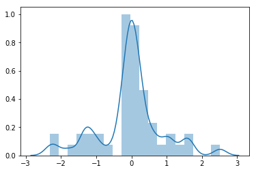

```python
rf_X_train_important = X_train[["HP","Proficiency"]]
rf_X_val_important = X_val[["HP","Proficiency"]]

rf_model_important = RandomForestRegressor(n_estimators=1000, random_state=1)
rf_model_important.fit(rf_X_train_important,y_train.values.ravel())

y_pred_rf_important = rf_model_important.predict(rf_X_val_important)
accuracy(y_pred_rf_important,y_val.CR.to_list())
```

In this case we have roughly the same quality of prediction as the multiple linear regression. This is a pretty small feature set, so I don't think that it is worth reducing the parameter space. Due to the low number of important features, and the ability to for multiple linear regression to do a good job, the next section is a little overkill. The point is to show how the hyperparameters of the ML learning model could be tuned if required.

## Tuning the hyperparameter space

At this point we want to sample the hyperparamter space of our random tree model to see if we can make increase the accuracy of our predictions. While doing so, we are going to include 3-fold cross-validation.

```python
# Number of trees in random forest
n_estimators = [int(x) for x in np.linspace(start = 200, stop = 2000, num = 10)]
# Number of features to consider at every split
max_features = ['auto', 'sqrt']
# Maximum number of levels in tree
max_depth = [int(x) for x in np.linspace(10, 110, num = 11)]
max_depth.append(None)
# Minimum number of samples required to split a node
min_samples_split = [2, 5, 10]
# Minimum number of samples required at each leaf node
min_samples_leaf = [1, 2, 4]
# Method of selecting samples for training each tree
bootstrap = [True, False]
# Create the random grid
random_grid = {'n_estimators': n_estimators,
               'max_features': max_features,
               'max_depth': max_depth,
               'min_samples_split': min_samples_split,
               'min_samples_leaf': min_samples_leaf,
               'bootstrap': bootstrap}
print(random_grid)
```

```
{'n_estimators': [200, 400, 600, 800, 1000, 1200, 1400, 1600, 1800, 2000], 'max_features': ['auto', 'sqrt'], 'max_depth': [10, 20, 30, 40, 50, 60, 70, 80, 90, 100, 110, None], 'min_samples_split': [2, 5, 10], 'min_samples_leaf': [1, 2, 4], 'bootstrap': [True, False]}
```

Run the randomized search over the hyperparameter space and print the best hyperparamters. This takes about 3 minutes.

```python
# Use the random grid to search for best hyperparameters
# First create the base model to tune
rf = RandomForestRegressor()
# Random search of parameters, using 3 fold cross validation,
# search across 100 different combinations, and use all available cores
rf_random = RandomizedSearchCV(estimator = rf, param_distributions = random_grid, n_iter = 100, cv = 3, verbose=2, random_state=1, n_jobs = -1)
# Fit the random search model
rf_random.fit(X_train, y_train)
rf_random.best_params_
```

```
Fitting 3 folds for each of 100 candidates, totalling 300 fits
```

```
[Parallel(n_jobs=-1)]: Using backend LokyBackend with 4 concurrent workers.
[Parallel(n_jobs=-1)]: Done  33 tasks      | elapsed:   29.1s
[Parallel(n_jobs=-1)]: Done 154 tasks      | elapsed:  1.7min
[Parallel(n_jobs=-1)]: Done 300 out of 300 | elapsed:  3.1min finished
```

```
{'n_estimators': 1600,
 'min_samples_split': 2,
 'min_samples_leaf': 1,
 'max_features': 'auto',
 'max_depth': 110,
 'bootstrap': True}
```

The best estimator was chose to be

```
{'n_estimators': 1600,
 'min_samples_split': 2,
 'min_samples_leaf': 1,
 'max_features': 'auto',
 'max_depth': 110,
 'bootstrap': True}
```

Checking the performance of this model gives the following:

```
Mean Abs Error = 0.46782015931372556
-0.12630667892156866 +/- 0.6887803568469258
```

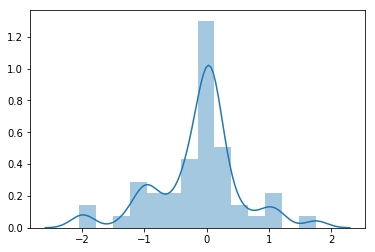

```python
best_random = rf_random.best_estimator_
y_pred_rf_best = best_random.predict(X_val)
accuracy(y_pred_rf_best,y_val.CR.to_list())
```

```python
# Create the parameter grid based on the results of random search
param_grid = {
    'bootstrap': [True],
    'max_depth': [90, 100, 110, 120, 130],
    'max_features': ['auto'],
    'min_samples_leaf': [1, 2, 3],
    'min_samples_split': [2, 3],
    'n_estimators': [1400, 1500, 1600, 1700, 1800]
}
# Create a based model
rf = RandomForestRegressor()
# Instantiate the grid search model
grid_search = GridSearchCV(estimator = rf, param_grid = param_grid, cv = 3, n_jobs = -1, verbose = 2)
# Fit the grid search to the data
grid_search.fit(X_train, y_train)
grid_search.best_params_
```

```
Fitting 3 folds for each of 150 candidates, totalling 450 fits
```

```
[Parallel(n_jobs=-1)]: Using backend LokyBackend with 4 concurrent workers.
[Parallel(n_jobs=-1)]: Done  33 tasks      | elapsed:   26.3s
[Parallel(n_jobs=-1)]: Done 154 tasks      | elapsed:  1.9min
[Parallel(n_jobs=-1)]: Done 357 tasks      | elapsed:  4.4min
[Parallel(n_jobs=-1)]: Done 450 out of 450 | elapsed:  5.4min finished
```

```
{'bootstrap': True,
 'max_depth': 130,
 'max_features': 'auto',
 'min_samples_leaf': 1,
 'min_samples_split': 2,
 'n_estimators': 1500}
```

Which is not much better than the original Random Forrest.

```
Mean Abs Error = 0.47147549019607826
-0.12667483660130724 +/- 0.6897602592285451
```

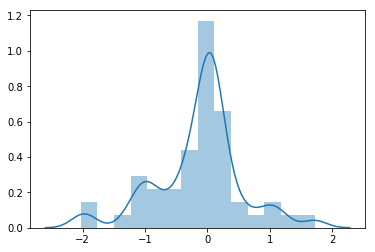

```python
best = grid_search.best_estimator_
y_pred_best = best.predict(X_val)
accuracy(y_pred_best,y_val.CR.to_list())
```

Again, this is not much better. This makes sense as it is clear that we only have two significant predictors for CR. These are HP and proficiency. However, attack strength should have some bearing on the CR for a monster. Clearly improvement is limited, and this will take quite major work to parse the actions. In the next book, `MonsterActionAnalysis.ipynb`, a study of how monsters attack will be completed.